# Comparison of dispersion estimation methods

The notebook reproduces the comparison of dispersion fitting in the csDEX article (Stražar & Curk, 2017), Supplementary Figure 4. For this experiment, csDEX and DEXSeq packages are required. A temporary directory is created in the current working directory.

```r
require(csDEX)
require(DEXSeq)
data.dir = file.path(getwd(), "csdex-temp/")
```

The terminology csDEX package estimates precisions (inverse dispersions), to keep a consistent terminology for both count and Percent Spliced-in (PSI) models, based on negative binomial and Beta distributions, respectively. Since csDEX assumes `sum` as the default replicate aggregation function, the estimated dispersion is multiplied by the number of replicates for correct comparison.

```r
dispersion.csdex <- function(obj, nreps=1){
  # obj: a list returned by the csDEX::generate function
  # nreps: number of replicates
  cdx = obj$data
  cdx = csDEX::estimateSizeFactors(cdx)
  cdx = csDEX::estimatePrecisions(cdx)
  disp = nreps / csDEX::rowData(cdx)$precision
  return(disp)
}
```

Estimating dispersion with DEXSeq (Anders et. al, 2012) is also straightforward. The count files are loaded from disk and a standard workflow is used to first estimate the size factors (differences in sample means due to sequencing depth) and the using the Cox-Reid dispersion estimate.

```r
dispersion.dexseq <- function(obj){
    # obj: a list returned by the csDEX::generate function
    # nreps: number of replicates
    sampleData = obj$design
    countfiles = file.path(obj$data.dir, "data", paste0(sampleData$File.accession, ".txt"))
    dex = DEXSeqDataSetFromHTSeq(
      countfiles = countfiles,
      sampleData = sampleData)
    dex = DEXSeq::estimateSizeFactors(dex)
    dex = DEXSeq::estimateDispersions(dex)
    disp = dispersions(dex)
    return(disp)
}
```

Generate a dataset with a fixed vector of `dispersions`. The values are the same for each of the `repeats`, enabling to compute mean predictions and standard deviations. The DEXSeq dispersion fitting can fail in the case of a large number of zero counts.

```r
conditions = 10
exons = 20
repeats = 30
replicates = 3
genes = 3

dispersions = rev(sort(rgamma(exons*genes, 1, 2.5)))

est.cdx = matrix(0, nrow=repeats, ncol=exons*genes)
est.dex = matrix(0, nrow=repeats, ncol=exons*genes)
for (r in 1:repeats){
  obj = generate(exons=exons, conditions=conditions,
                   interacting=0, replicates=replicates, genes=genes,
                   dispersions = dispersions,
                   type="count", data.dir=data.dir)

  est.cdx[r,] = dispersion.csdex(obj, replicates)
  est.dex[r,] = tryCatch(dispersion.dexseq(obj),
                          error=function(e) rep(NA, exons))
}
```

```r
  x = 1:(exons*genes)
  mean.cdx = colMeans(est.cdx)
  std.cdx = apply(est.cdx, 2, sd)
  down.cdx = mean.cdx + std.cdx
  up.cdx = mean.cdx - std.cdx
  rmse.cdx = sqrt(sum((mean.cdx - dispersions)^2))

  est.dex[est.dex > 3] = NA
  mean.dex = colMeans(est.dex, na.rm=TRUE)
  std.dex = apply(est.dex, 2, sd, na.rm=TRUE)
  down.dex = mean.dex + std.dex
  up.dex = mean.dex - std.dex
  rmse.dex = sqrt(sum((mean.dex - dispersions)^2))

  plot(dispersions, type="l", col="black", xlab="Exon", ylab="Dispersion",
       main = sprintf("Conditions: %d", conditions))
  op = par(cex = 0.8)
```

```r
  lines(mean.cdx, col="orange")
  lines(mean.dex, col="blue")
```

```r
  polygon(c(x, rev(x)), c(up.cdx, rev(down.cdx)), col=rgb(1,0,0,0.2), border=NA)
  polygon(c(x, rev(x)), c(up.dex, rev(down.dex)), col=rgb(0,0,1,0.2), border=NA)
```

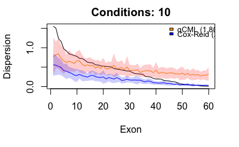

```r
  legend("topright", inset=.01,
         c(sprintf("qCML (%.2f)", rmse.cdx), sprintf("Cox-Reid (%.2f)", rmse.dex)),
         fill=c("orange", "blue"), bty="n")
```